# Causal Arima Intro

## Excercise

On October 4, 2018 the Florence branch of an Italian supermarket chain introduced a price policy change on several store-brand products by permanently reducing their price. Your goal is to estimate the causal effect of the price policy change on the sales of one of the addressed products.

- Data

The data set includes the daily sales of one product from September 2017 to April 2019, its price and information on national holidays and already built-in day-of-the-week dummies.

Dates : vector of dates Sales : time series of daily sales counts (number of units sold) TruePrice : the true unit price of the product Price : the new unit price series, set to a constant value in the post-intervention period hol : holiday dummy taking value 1 before and after a national Italian holiday dec.sun : dummy taking value 1 on December Sundays sat–thr : day-of-the-week dummies

- Questions
  1. What is the total number of units sold due to the price reduction after 1-week, 1 month and 3 months from the intervention?
  2. What is the total number of units sold at the end of the analysis period?
  3. Plot the causal effect and residual diagnostics
  4. Assume a multiplicative effect, how much more did the product sold due to the permanent price reduction?
- R Package

The suggested R package is `CausalArima`, you can install the development version from GitHub with

```r
# install.packages("devtools")
# devtools::install_github("FMenchetti/CausalArima")
```

## Prepare Notebook

```r
library("CausalArima")
library("tidyverse")
```

## Read Data

```r
raw_data_df <- read_csv(file = "../../data/btsa-causalarima_2021-11-02_2033/dataset.csv")
raw_data_df %>% head()
```

```
## # A tibble: 6 × 13
##   Index Dates      Sales TruePrice Price   hol dec.sun   sat   sun   mon   tue
##   <dbl> <date>     <dbl>     <dbl> <dbl> <dbl>   <dbl> <dbl> <dbl> <dbl> <dbl>
## 1     1 2017-09-01  1250      1.39  1.39     0       0     0     0     0     0
## 2     2 2017-09-02  1752      1.38  1.38     0       0     1     0     0     0
## 3     3 2017-09-03   417      1.38  1.38     0       0     0     1     0     0
## 4     4 2017-09-04  1346      1.38  1.38     0       0     0     0     1     0
## 5     5 2017-09-05  1144      1.37  1.37     0       0     0     0     0     1
## 6     6 2017-09-06  1237      1.38  1.38     0       0     0     0     0     0
## # … with 2 more variables: wed <dbl>, thr <dbl>
```

## EDA

```r
data_df <- raw_data_df %>%
  mutate(
    price_change =  (TruePrice != Price),
    days_since_price_change = cumsum(as.numeric(price_change))
  )
```

```r
# date on which prices changed
price_change_date <- data_df %>%
  filter(price_change) %>%
  pull(Dates) %>%
  min()
```

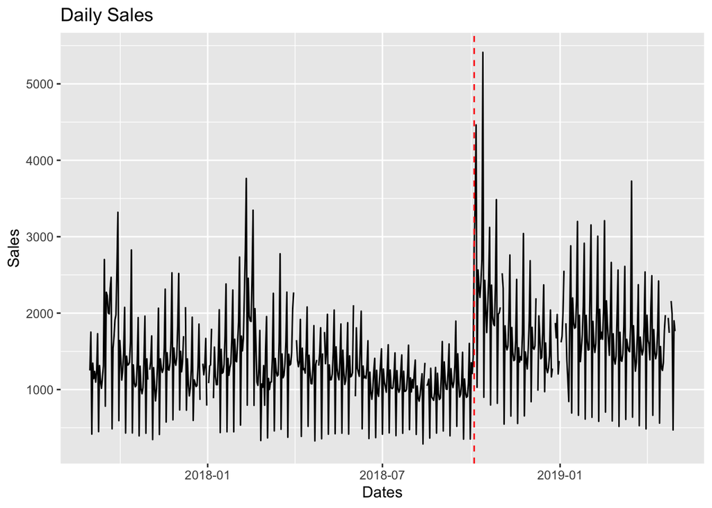

```r
ggplot(data=data_df) +
  geom_line(mapping = aes(x = Dates, y = Sales), color="black") +
  geom_vline(xintercept = price_change_date, color = "red", linetype="dashed") +
  ggtitle(label = "Daily Sales")
```

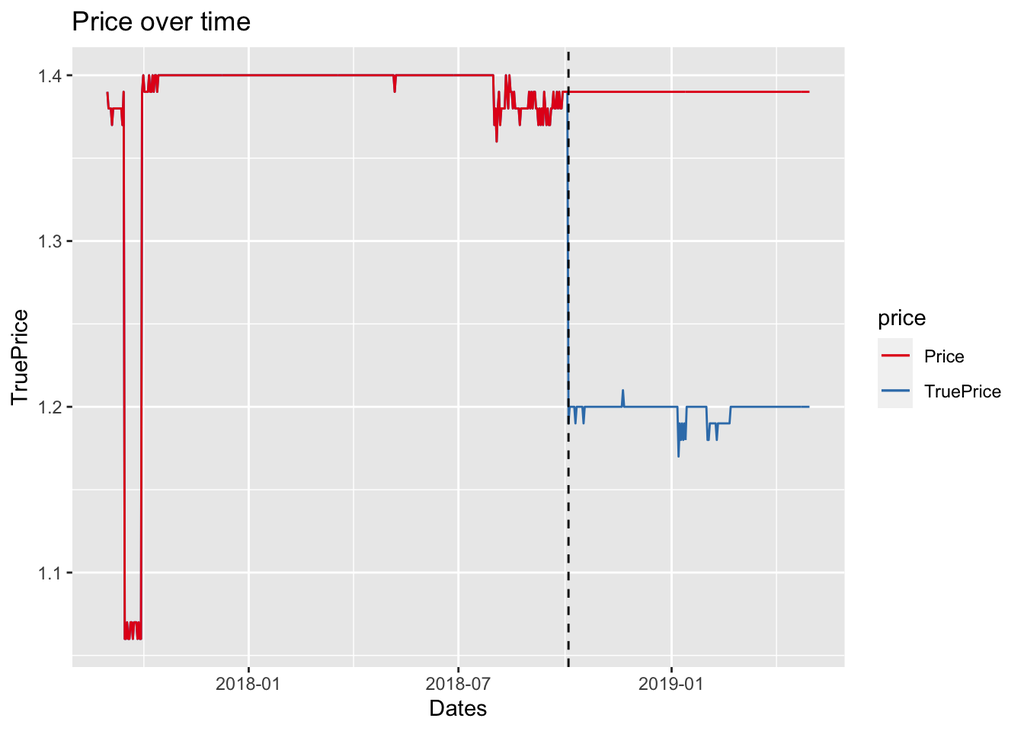

```r
ggplot(data=data_df) +
  geom_line(mapping = aes(x = Dates, y = TruePrice,  color="TruePrice")) +
  geom_line(mapping = aes(x = Dates, y = Price, color="Price")) +
  geom_vline(xintercept = price_change_date, color = "black", linetype="dashed") +
  scale_color_brewer(palette="Set1") +
  labs(title="Price over time", color="price")
```

## Answers

```
1.  What is the total number of units sold due to the price
    reduction after 1-week, 1 month and 3 months from the
    intervention?
```

```r
compute_sales_after_price_change <- function ( .df , day_window ) {

  .df_filtered <- .df %>% filter(price_change & days_since_price_change <= day_window)

  sales_day_window <- .df_filtered %>%
    summarise(Sales = sum(Sales, na.rm = TRUE)) %>%
    pull(Sales)

  return( sales_day_window )
}

compute_sales_after_price_change(.df = data_df, day_window = 7)
```

```
## [1] 18892
```

[figure not shown]

```
2.  What is the total number of units sold at the end of the
    analysis period?
```

```r
day_windows <- c(7, 30, 90, 120, 180)

tibble(
  day_windows = day_windows,
  sales = day_windows %>% map_dbl(function (x) compute_sales_after_price_change(.df = data_df, day_window = x))
) %>%
ggplot() +
  geom_line(mapping = aes(x = day_windows, y = sales), color="blue") +
  geom_point(mapping = aes(x = day_windows, y = sales), color="blue") +
  labs(title="Sales since price change")
```

```r
total_number_sold_end <- compute_sales_after_price_change(
  .df = data_df,
  day_window = (data_df %>% filter(price_change) %>% nrow())
)

total_number_sold_end
```

```
## [1] 351520
```

```
3.  Plot the causal effect and residual diagnostics
```

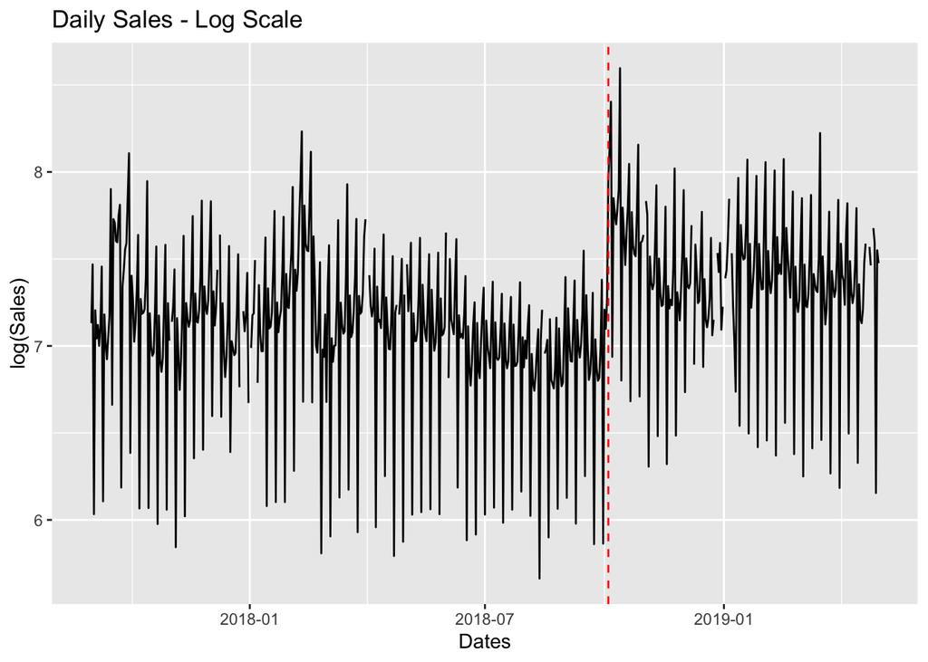

```r
ggplot(data=data_df) +
  geom_line(mapping = aes(x = Dates, y = log(Sales)), color="black") +
  geom_vline(xintercept = price_change_date, color = "red", linetype="dashed") +
  ggtitle(label = "Daily Sales - Log Scale")
```

```r
y <- ts(data =(data_df %>% pull(Sales)), frequency = 1)
log_y <- log(y)
dates <- data_df %>% pull(Dates)
x_reg <- data_df %>% select(hol, dec.sun, sat, sun, mon, tue, wed, thr)

ce <- CausalArima(
  y = log_y,
  auto = TRUE,
  dates = dates,
  int.date = price_change_date,
  xreg = x_reg
)
```

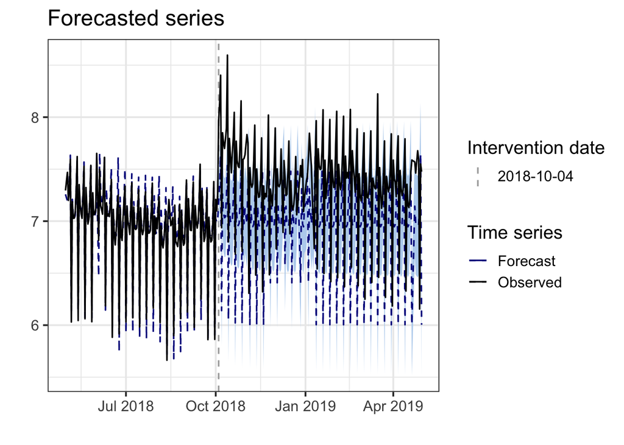

```r
forecasted <- plot(ce, type = "forecast")

forecasted
```

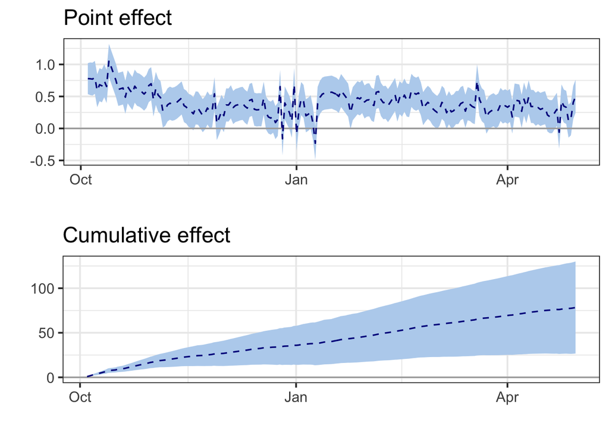

```r
impact_p <- plot(ce, type  ="impact")

grid.arrange(impact_p$plot, impact_p$cumulative_plot)
```

```r
ce$model$coef
```

```
##         ar1         ar2         ar3         ar4         ma1         hol
##  0.66061551  0.09080683  0.03509600  0.03241896 -0.98581787  0.16782933
##     dec.sun         sat         sun         mon         tue         wed
##  0.40323700  0.29928416 -1.17570384 -0.03646168 -0.20780285 -0.23404033
##         thr
## -0.21133073
```

```
4.  Assume a multiplicative effect, how much more did the product sold due to the
    permanent price reduction?
```

Let us denote by $y_{i}$ and $\hat{y}_{i}$ the observed and the forecasted time series of the arima model. Hence, the *causal effect* is given by:

$$ce_{i} = \log(y_{i}) - \log(\hat{y}_{i}) = \log\left(\frac{y_{i}}{\hat{y}_{i}}\right)$$
Therefore

$$\exp(ce_{i}) = \frac{y_{i}}{\hat{y}_{i}} \Longrightarrow \hat{y}_{i} = \frac{y_{i}}{\exp(ce_{i})}$$

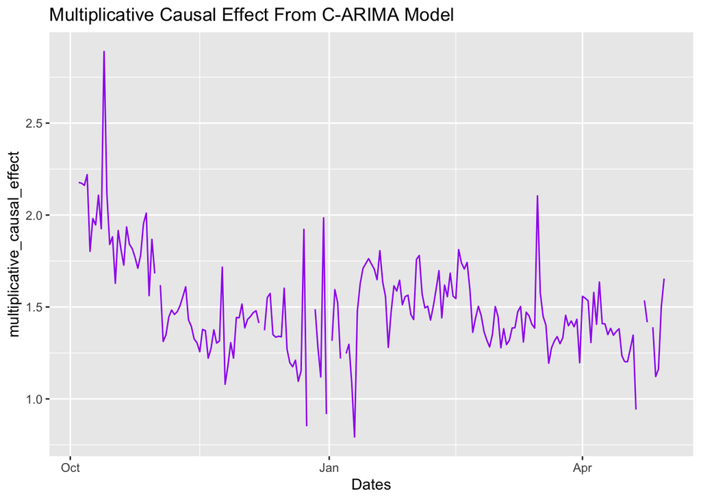

```r
multiplicative_causal_effect <- ce$causal.effect  %>% exp()

price_changed_data_df <- data_df %>%
  filter(price_change) %>%
  mutate(
    multiplicative_causal_effect = multiplicative_causal_effect,
    sales_estimated_no_price_change = Sales / multiplicative_causal_effect,
    causal_effect = Sales - sales_estimated_no_price_change
  )

ggplot(data = price_changed_data_df) +
  geom_line(mapping = aes(x = Dates, y = multiplicative_causal_effect), color = "purple") +
  labs(title = "Multiplicative Causal Effect From C-ARIMA Model")
```

```r
causal_effect <- price_changed_data_df %>%
  summarise(causal_effect = sum(causal_effect, na.rm = TRUE)) %>%
  pull(causal_effect)
```

```r
print(glue::glue(
"In the change of price period there were {total_number_sold_end} from where we estimate {round(causal_effect)} were caused by the price change. This accounts for {round( 100 * causal_effect / total_number_sold_end, digits=2)}% of the sales during this period."
))
```

```
## In the change of price period there were 351520 from where we estimate 117717 were caused by the price change. This accounts for 33.49% of the sales during this period.
```

## Compare with CausalImpact

```r
library("CausalImpact")
ci_data <- data_df %>%
  mutate(Sales = log(Sales)) %>%
  dplyr::select(Sales, hol, dec.sun, sat, sun, mon, tue, wed, thr) %>%
  fill(Sales, .direction = "down")

pre_period <- c(1, data_df %>% dplyr::filter(price_change) %>% pull(Index) %>% first() - 1)

post_period <-  c(pre_period[2] + 1, data_df %>% pull(Index) %>% last())


ci <- CausalImpact(
  data = zoo(ci_data),
  pre.period = pre_period,
  post.period = post_period
)

summary(ci)
```

```
## Posterior inference {CausalImpact}
##
##                          Average         Cumulative
## Actual                   7.4             1544.5
## Prediction (s.d.)        7 (0.31)        1467 (63.92)
## 95% CI                   [6.4, 7.6]      [1342.6, 1591.4]
##
## Absolute effect (s.d.)   0.37 (0.31)     77.25 (63.92)
## 95% CI                   [-0.22, 0.97]   [-46.96, 201.94]
##
## Relative effect (s.d.)   5.3% (4.4%)     5.3% (4.4%)
## 95% CI                   [-3.2%, 14%]    [-3.2%, 14%]
##
## Posterior tail-area probability p:   0.12364
## Posterior prob. of a causal effect:  88%
##
## For more details, type: summary(impact, "report")
```

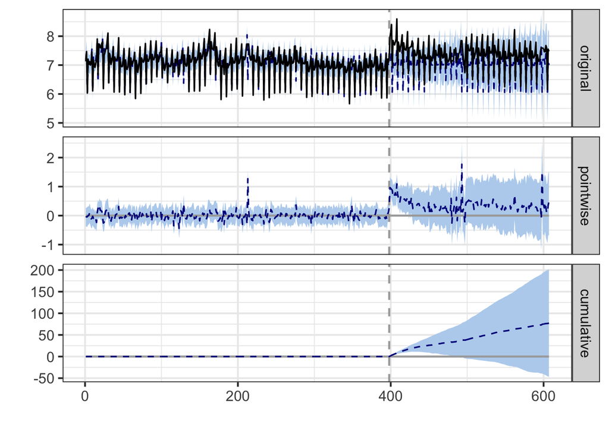

```r
plot(ci)
```

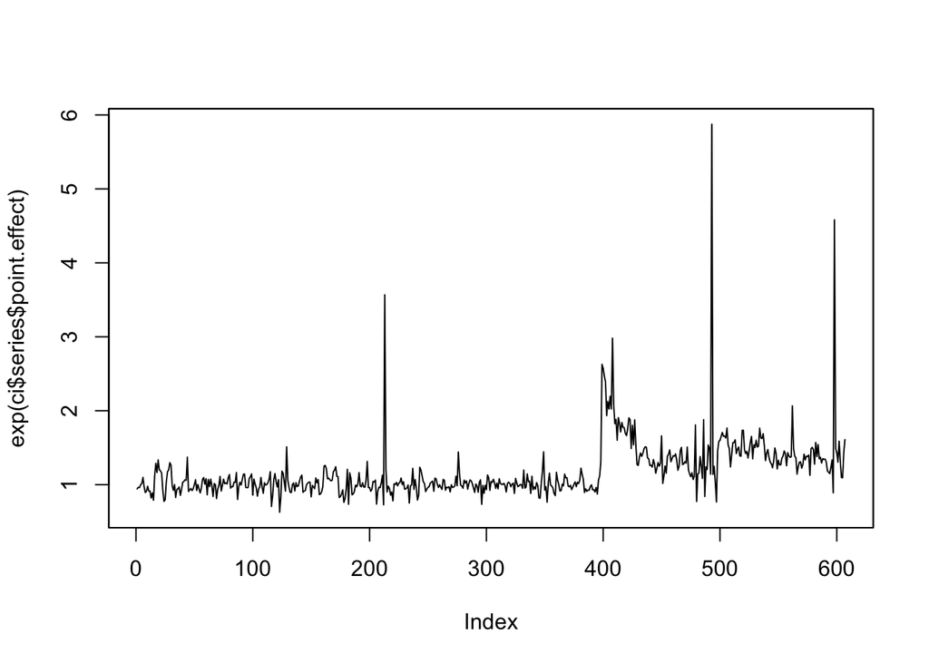

```r
plot(exp(ci$series$point.effect))
```